# Title: Wine Quality Whites

```
## [1] "C"
```

```r
# 查看数据集构成
str(ww)
```

```
## 'data.frame':    4898 obs. of  13 variables:
##  $ X                   : int  1 2 3 4 5 6 7 8 9 10 ...
##  $ fixed.acidity       : num  7 6.3 8.1 7.2 7.2 8.1 6.2 7 6.3 8.1 ...
##  $ volatile.acidity    : num  0.27 0.3 0.28 0.23 0.23 0.28 0.32 0.27 0.3 0.22 ...
##  $ citric.acid         : num  0.36 0.34 0.4 0.32 0.32 0.4 0.16 0.36 0.34 0.43 ...
##  $ residual.sugar      : num  20.7 1.6 6.9 8.5 8.5 6.9 7 20.7 1.6 1.5 ...
##  $ chlorides           : num  0.045 0.049 0.05 0.058 0.058 0.05 0.045 0.045 0.049 0.044 ...
##  $ free.sulfur.dioxide : num  45 14 30 47 47 30 30 45 14 28 ...
##  $ total.sulfur.dioxide: num  170 132 97 186 186 97 136 170 132 129 ...
##  $ density             : num  1.001 0.994 0.995 0.996 0.996 ...
##  $ pH                  : num  3 3.3 3.26 3.19 3.19 3.26 3.18 3 3.3 3.22 ...
##  $ sulphates           : num  0.45 0.49 0.44 0.4 0.4 0.44 0.47 0.45 0.49 0.45 ...
##  $ alcohol             : num  8.8 9.5 10.1 9.9 9.9 10.1 9.6 8.8 9.5 11 ...
##  $ quality             : int  6 6 6 6 6 6 6 6 6 6 ...
```

```r
# 查看数据集的统计信息
summary(ww)
```

```
##        X        fixed.acidity    volatile.acidity  citric.acid
##  Min.   :   1   Min.   : 3.800   Min.   :0.0800   Min.   :0.0000
##  1st Qu.:1225   1st Qu.: 6.300   1st Qu.:0.2100   1st Qu.:0.2700
##  Median :2450   Median : 6.800   Median :0.2600   Median :0.3200
##  Mean   :2450   Mean   : 6.855   Mean   :0.2782   Mean   :0.3342
##  3rd Qu.:3674   3rd Qu.: 7.300   3rd Qu.:0.3200   3rd Qu.:0.3900
##  Max.   :4898   Max.   :14.200   Max.   :1.1000   Max.   :1.6600
##  residual.sugar     chlorides       free.sulfur.dioxide
##  Min.   : 0.600   Min.   :0.00900   Min.   :  2.00
##  1st Qu.: 1.700   1st Qu.:0.03600   1st Qu.: 23.00
##  Median : 5.200   Median :0.04300   Median : 34.00
##  Mean   : 6.391   Mean   :0.04577   Mean   : 35.31
##  3rd Qu.: 9.900   3rd Qu.:0.05000   3rd Qu.: 46.00
##  Max.   :65.800   Max.   :0.34600   Max.   :289.00
##  total.sulfur.dioxide    density             pH          sulphates
##  Min.   :  9.0        Min.   :0.9871   Min.   :2.720   Min.   :0.2200
##  1st Qu.:108.0        1st Qu.:0.9917   1st Qu.:3.090   1st Qu.:0.4100
##  Median :134.0        Median :0.9937   Median :3.180   Median :0.4700
##  Mean   :138.4        Mean   :0.9940   Mean   :3.188   Mean   :0.4898
##  3rd Qu.:167.0        3rd Qu.:0.9961   3rd Qu.:3.280   3rd Qu.:0.5500
##  Max.   :440.0        Max.   :1.0390   Max.   :3.820   Max.   :1.0800
##     alcohol         quality
##  Min.   : 8.00   Min.   :3.000
##  1st Qu.: 9.50   1st Qu.:5.000
##  Median :10.40   Median :6.000
##  Mean   :10.51   Mean   :5.878
##  3rd Qu.:11.40   3rd Qu.:6.000
##  Max.   :14.20   Max.   :9.000
```

我们的数据集由12个变量组成，具有4898个观测值。

# 单变量绘图选择

1.质量的柱状图

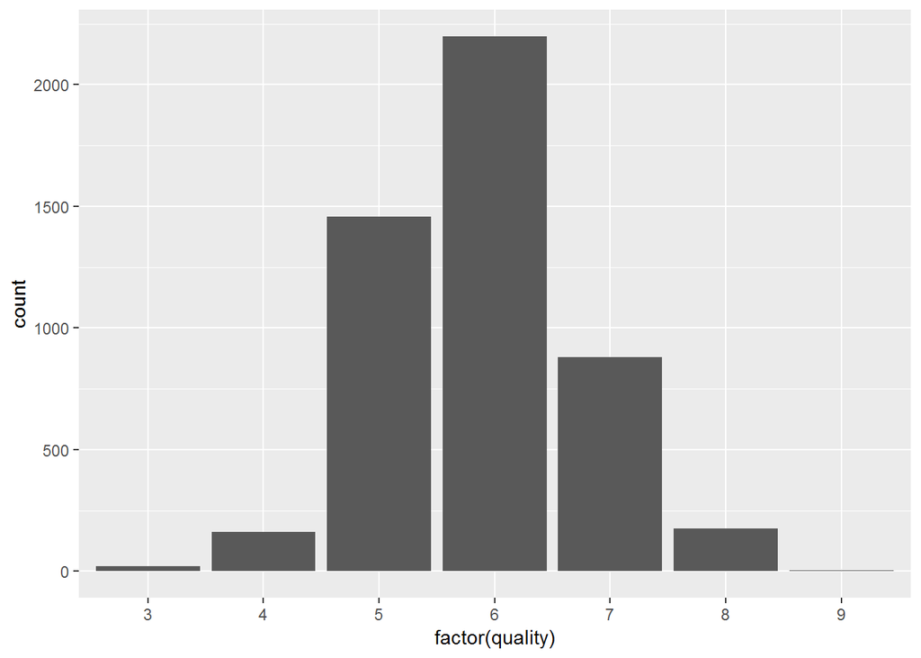

```r
# 查看 quality 的统计信息
summary(ww$quality)
```

```
##    Min. 1st Qu.  Median    Mean 3rd Qu.    Max.
##   3.000   5.000   6.000   5.878   6.000   9.000
```

白葡萄酒的质量评分的分布近似于正态分布，大多数在5分~7分之间，中位数为6分， 平均数为5.878分。

2.固定酸度的直方图

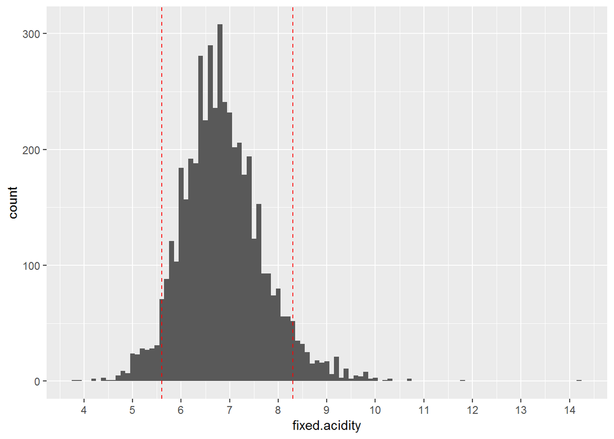

```r
# 绘制 fixed.acidity 的直方图
ggplot(aes(x = fixed.acidity), data = ww) +
  # 设置直方图宽度
  geom_histogram(binwidth = 0.1) +
  # 设置x轴范围和坐标值
  scale_x_continuous(breaks = seq(3,14.2,1)) +
  # 绘制 5% 和 95% 的分位数
  geom_vline(xintercept = quantile(ww$fixed.acidity,probs = 0.05,na.rm = T),
             linetype = 'dashed', color = 'red') +
  geom_vline(xintercept = quantile(ww$fixed.acidity,probs = 0.95,na.rm = T),
             linetype = 'dashed', color = 'red')
```

```r
# 查看 fixed.acidity 的统计信息
summary(ww$fixed.acidity)
```

```
##    Min. 1st Qu.  Median    Mean 3rd Qu.    Max.
##   3.800   6.300   6.800   6.855   7.300  14.200
```

固定酸度的分布近似于正态分布，大多数在5.5~8.0之间，中位数为6.8，平均数为6.855。

3.挥发性酸度的直方图

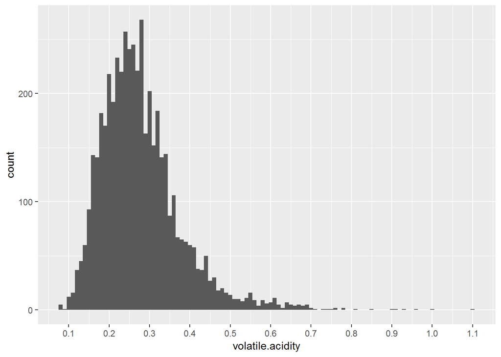

```r
# 绘制 volatile.acidity 的直方图
ggplot(aes(x = volatile.acidity), data = ww) +
  # 设置直方图宽度
  geom_histogram(binwidth = 0.01) +
  # 设置x轴范围和坐标值
  scale_x_continuous(breaks = seq(0,1.1,0.1))
```

```r
# 查看 volatile.acidity 的统计信息
summary(ww$volatile.acidity)
```

```
##    Min. 1st Qu.  Median    Mean 3rd Qu.    Max.
##  0.0800  0.2100  0.2600  0.2782  0.3200  1.1000
```

挥发性酸度的分布近似于正态分布，大多数在0.15~0.4之间，中位数为0.26， 平均数为0.2782。

4.柠檬酸的直方图

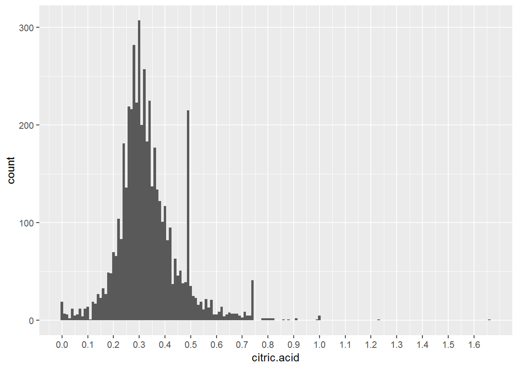

```r
# 绘制 citric.acid 的直方图
ggplot(aes(x = citric.acid), data = ww) +
  # 设置直方图宽度
  geom_histogram(binwidth = 0.01) +
  # 设置x轴范围和坐标值
  scale_x_continuous(breaks = seq(0,1.66,0.1))
```

柠檬酸的分布近似于正态分布，大多数在0.2~0.5之间，但在0值处存在一些显著异常点。

```r
# 查看 citric.acid 的统计信息
summary(ww$citric.acid == 0)
```

```
##    Mode   FALSE    TRUE
## logical    4879      19
```

柠檬酸有19个数据缺失，显示值为0。以下是具体明细。

```r
# 查看所有 citric.acid 为 0 的值
ww[ww$citric.acid == 0,]
```

```
##         X fixed.acidity volatile.acidity citric.acid residual.sugar
## 116   116           5.5            0.485           0            1.5
## 301   301           6.1            0.410           0            1.6
## 303   303           6.1            0.410           0            1.6
## 781   781           6.0            0.395           0            1.4
## 863   863           4.8            0.340           0            6.5
## 865   865           4.8            0.330           0            6.5
## 891   891           5.0            0.310           0            6.4
## 1153 1153           6.1            0.600           0            1.3
## 1818 1818           7.2            0.500           0            0.8
## 2322 2322           4.6            0.445           0            1.4
## 2630 2630           5.8            0.600           0            1.3
## 3455 3455           5.8            0.540           0            1.4
## 3572 3572           5.9            0.655           0            5.6
## 3636 3636           5.8            0.580           0            1.5
```

[output cut: 45 more lines]

从以上数据得知，除了 citric.acid 值为 0，其他变量值都是正常的数据， 故认为这些行是 citric.acid 数据缺少异常值。

5.残糖的直方图

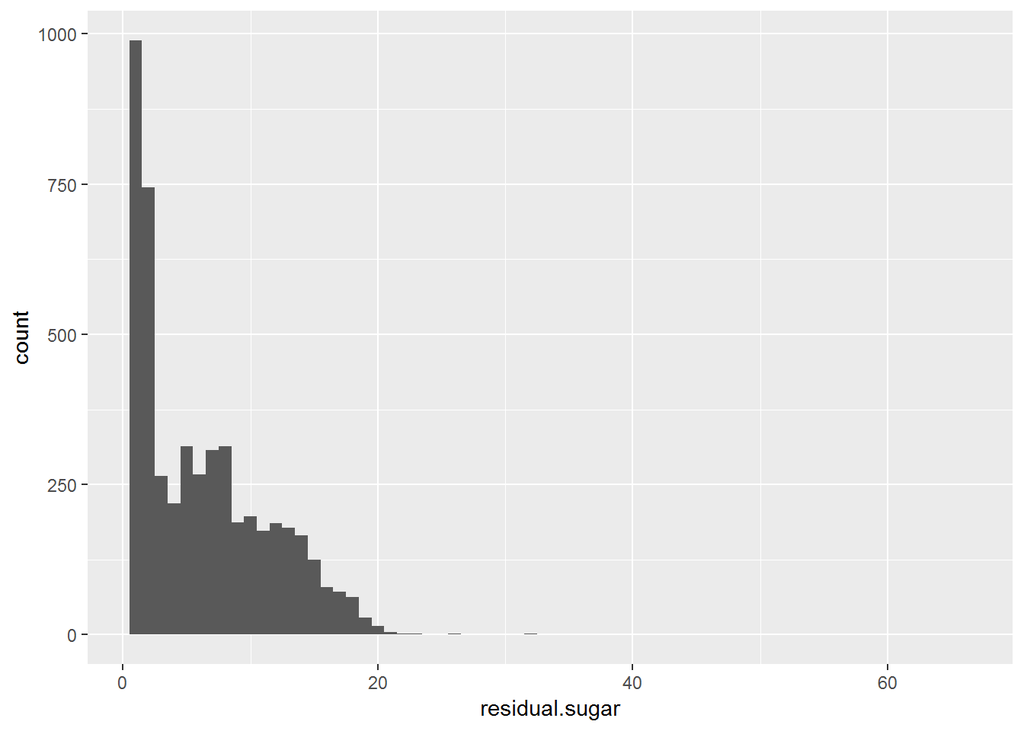

```r
# 绘制 residual.sugar 的直方图
ggplot(aes(x = residual.sugar), data = ww) +
  # 设置直方图宽度
  geom_histogram(binwidth = 1)
```

分布图是右偏分布，故需对x值进行log转换，转换长尾数据以更好地了解残糖分布。

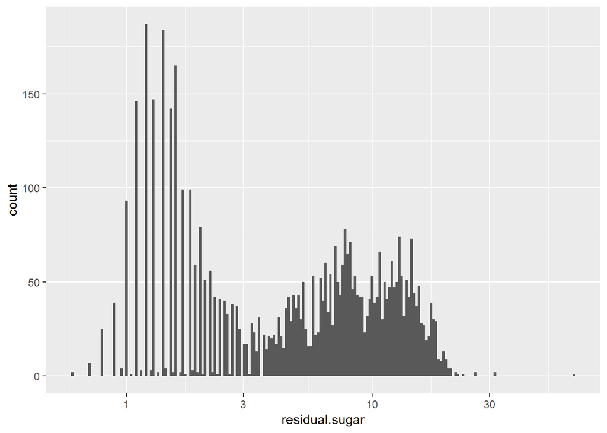

```r
# 绘制 residual.sugar 值log转换的直方图
ggplot(aes(x = residual.sugar), data = ww) +
  # 设置直方图宽度
  geom_histogram(binwidth = 0.01) +
  # 对x值进行log10转换
  scale_x_log10()
```

转换残糖分布是双峰分布，残糖含量大约在2左右和10左右。

```r
# 查看 residual.sugar 的统计信息
summary(ww$residual.sugar)
```

```
##    Min. 1st Qu.  Median    Mean 3rd Qu.    Max.
##   0.600   1.700   5.200   6.391   9.900  65.800
```

残糖的最小值为0.6，最大值为65.8，中位数为5.2，平均数为6.391。

6.氯化物的直方图

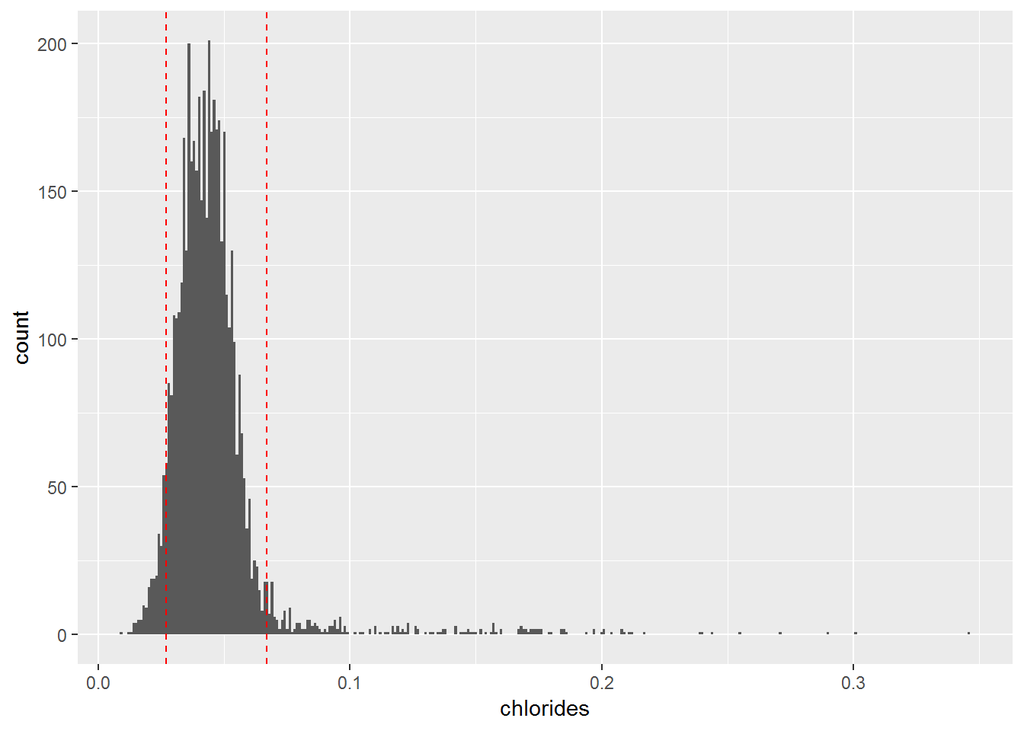

```r
# 绘制 chlorides 的直方图
ggplot(aes(x = chlorides), data = ww) +
  # 设置直方图宽度
  geom_histogram(binwidth = 0.001) +
  scale_x_continuous()  +
  # 绘制 5% 和 95% 的分位数
  geom_vline(xintercept = quantile(ww$chlorides,probs = 0.05,na.rm = T),
             linetype = 'dashed', color = 'red') +
  geom_vline(xintercept = quantile(ww$chlorides,probs = 0.95,na.rm = T),
             linetype = 'dashed', color = 'red')
```

限制x轴的范围，放大分布图

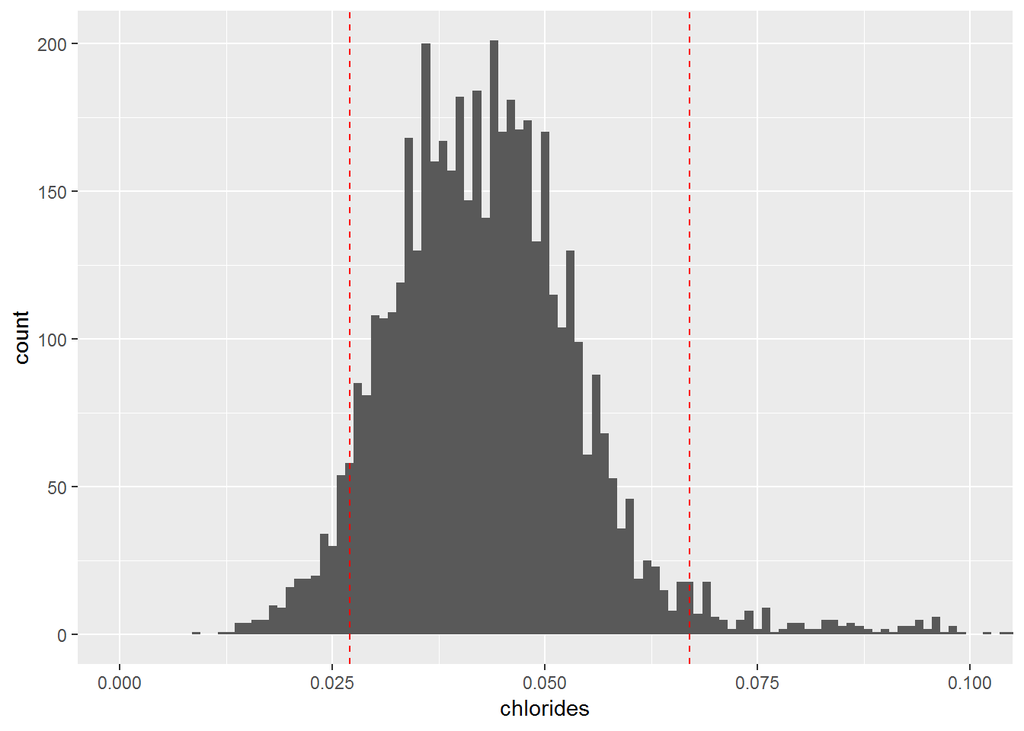

```r
# 绘制 chlorides 的直方图
ggplot(aes(x = chlorides), data = ww) +
  # 设置直方图宽度
  geom_histogram(binwidth = 0.001) +
  scale_x_continuous() +
  # 绘制 5% 和 95% 的分位数
  geom_vline(xintercept = quantile(ww$chlorides,probs = 0.05,na.rm = T),
             linetype = 'dashed', color = 'red') +
  geom_vline(xintercept = quantile(ww$chlorides,probs = 0.95,na.rm = T),
             linetype = 'dashed', color = 'red') +
  # 限制x轴的范围
  coord_cartesian(xlim = c(0,0.1))
```

```r
# 查看 chlorides 的统计信息
summary(ww$chlorides)
```

```
##    Min. 1st Qu.  Median    Mean 3rd Qu.    Max.
## 0.00900 0.03600 0.04300 0.04577 0.05000 0.34600
```

氯化物的分布近似于正态分布，大多数在0.03~0.06之间，最小值为0.009， 最大值为0.346，中位数为0.043，平均数为0.04577。

7.密度的直方图

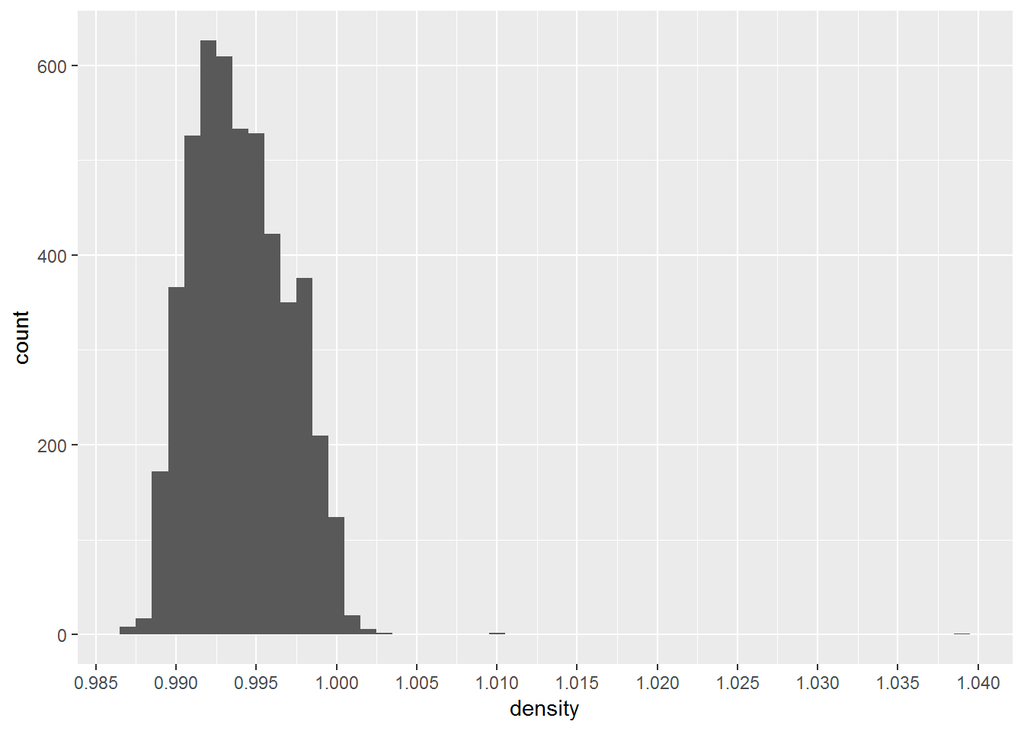

```r
# 绘制 density 的直方图
ggplot(aes(x = density), data = ww) +
  # 设置直方图宽度
  geom_histogram(binwidth = 0.001) +
  # 设置x轴范围和坐标值
  scale_x_continuous(breaks = seq(0.98,1.04,0.005))
```

```r
# 查看 density 的统计信息
summary(ww$density)
```

```
##    Min. 1st Qu.  Median    Mean 3rd Qu.    Max.
##  0.9871  0.9917  0.9937  0.9940  0.9961  1.0390
```

密度的分布近似于正态分布，大多数在0.99~1之间，中位数为0.9937，平均数为0.9940。

8.pH的直方图

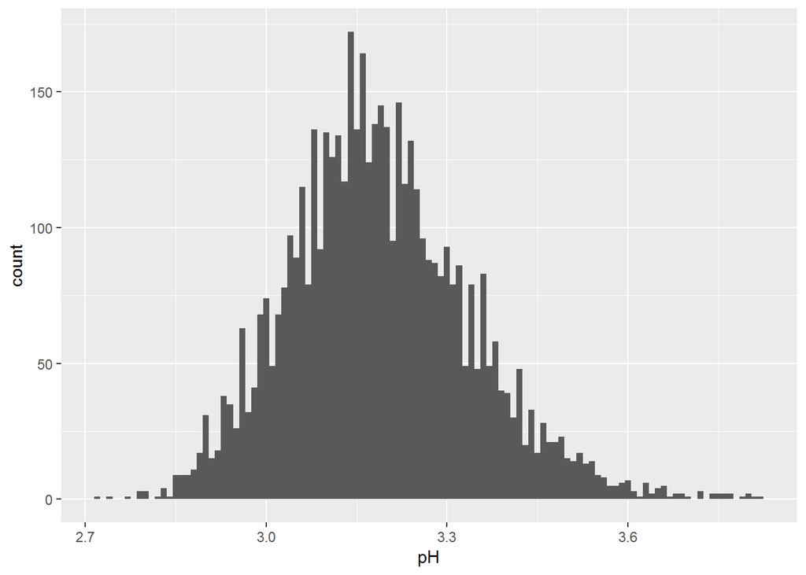

```r
# 绘制 pH 的直方图
ggplot(aes(x = pH), data = ww) +
  # 设置直方图宽度
  geom_histogram(binwidth = 0.01) +
  scale_x_continuous()
```

```r
# 查看 pH 的统计信息
summary(ww$pH)
```

```
##    Min. 1st Qu.  Median    Mean 3rd Qu.    Max.
##   2.720   3.090   3.180   3.188   3.280   3.820
```

pH的分布近似于正态分布，大多数在3~3.4之间，中位数为3.18，平均数为3.188。

9.硫酸盐的直方图

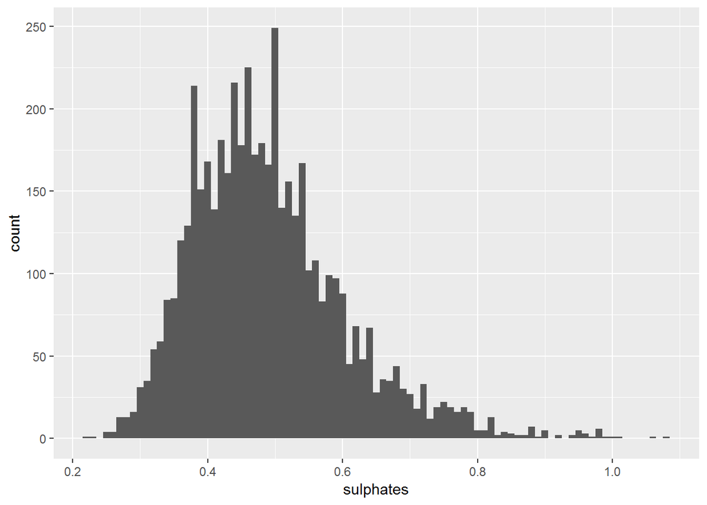

```r
# 绘制 sulphates 的直方图
ggplot(aes(x = sulphates), data = ww) +
  # 设置直方图宽度
  geom_histogram(binwidth = 0.01) +
  scale_x_continuous()
```

```r
# 查看 sulphates 的统计信息
summary(ww$sulphates)
```

```
##    Min. 1st Qu.  Median    Mean 3rd Qu.    Max.
##  0.2200  0.4100  0.4700  0.4898  0.5500  1.0800
```

硫酸盐的分布近似于正态分布，大多数在0.35~0.6之间，中位数为0.47，平均数为0.4898。

10.酒精的直方图

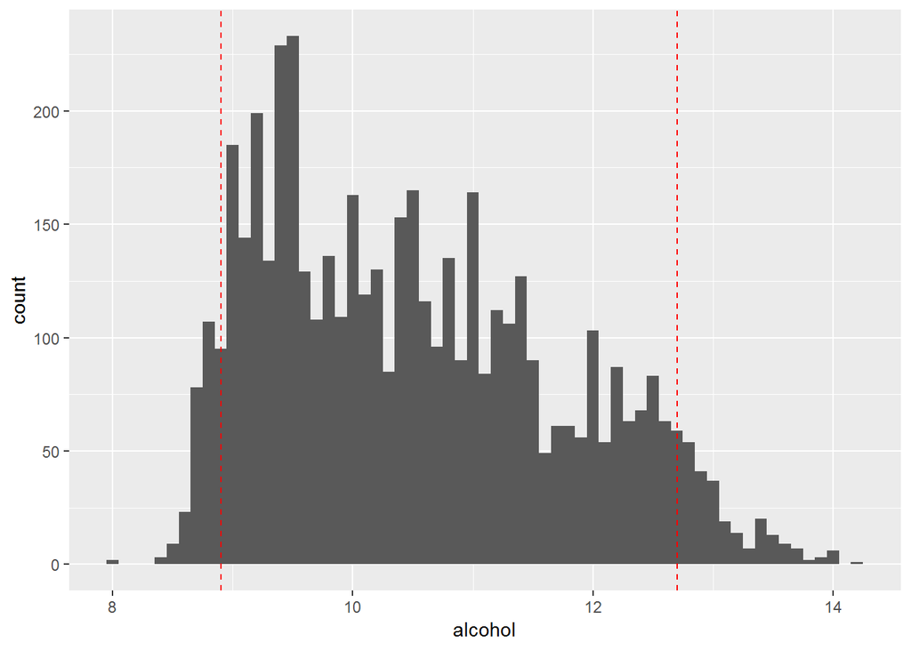

```r
# 绘制 alcohol 的直方图
ggplot(aes(x = alcohol), data = ww) +
  # 设置直方图宽度
  geom_histogram(binwidth = 0.1) +
  scale_x_continuous() +
  # 绘制 5% 和 95% 的分位数
  geom_vline(xintercept = quantile(ww$alcohol,probs = 0.05,na.rm = T),
             linetype = 'dashed', color = 'red') +
  geom_vline(xintercept = quantile(ww$alcohol,probs = 0.95,na.rm = T),
             linetype = 'dashed', color = 'red')
```

酒精的的分面图中可知，大多数在9~12之间。对酒精分布图进行分面处理。

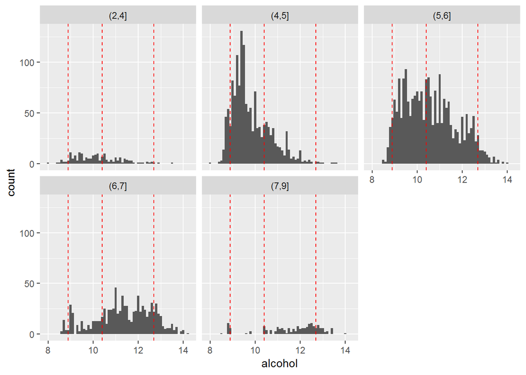

```r
# 把 quality 整数值改成 因子变量
ww$quality.f <- cut(ww$quality, breaks = c(2,4,5,6,7,9))

# 绘制 alcohol 的分面直方图
ggplot(aes(x = alcohol), data = ww) +
  # 设置直方图宽度
  geom_histogram(binwidth = 0.1) +
  scale_x_continuous() +
  # 绘制 5% ， 50% 和 95% 的分位数数
  geom_vline(xintercept = quantile(ww$alcohol,probs = 0.05,na.rm = T),
             linetype = 'dashed', color = 'red') +
  geom_vline(xintercept = quantile(ww$alcohol,probs = 0.50,na.rm = T),
             linetype = 'dashed', color = 'red') +
  geom_vline(xintercept = quantile(ww$alcohol,probs = 0.95,na.rm = T),
             linetype = 'dashed', color = 'red') +
  # 对 alcohol 进行分面
  facet_wrap(~quality.f)
```

11.游离二氧化硫的直方图

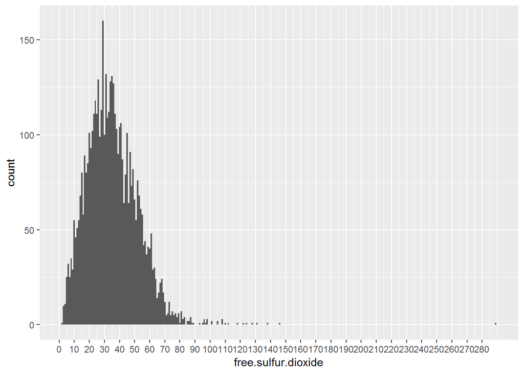

```r
# 绘制 free.sulfur.dioxide 的直方图
ggplot(aes(x = free.sulfur.dioxide), data = ww) +
  # 设置直方图宽度
  geom_histogram(binwidth = 1) +
  # 设置x轴范围和坐标值
  scale_x_continuous(breaks = seq(0,289,10))
```

```r
# 查看 free.sulfur.dioxide 的统计信息
summary(ww$free.sulfur.dioxide)
```

```
##    Min. 1st Qu.  Median    Mean 3rd Qu.    Max.
##    2.00   23.00   34.00   35.31   46.00  289.00
```

游离二氧化硫的分布近似于正态分布，大多数在20~50之间，中位数为34，平均数为35.31。

12.总二氧化硫的直方图

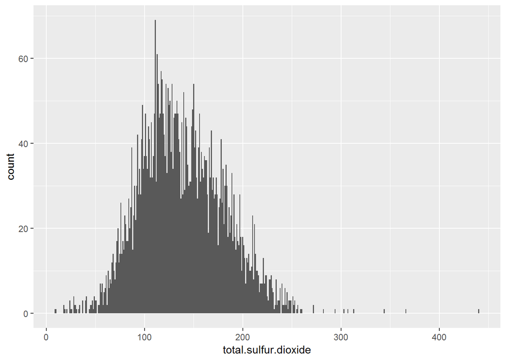

```r
# 绘制 total.sulfur.dioxide 的直方图
ggplot(aes(x = total.sulfur.dioxide), data = ww) +
  # 设置直方图宽度
  geom_histogram(binwidth = 1) +
  # 设置x轴范围和坐标值
  scale_x_continuous()
```

```r
# 查看 total.sulfur.dioxide 的统计信息
summary(ww$total.sulfur.dioxide)
```

```
##    Min. 1st Qu.  Median    Mean 3rd Qu.    Max.
##     9.0   108.0   134.0   138.4   167.0   440.0
```

13.创建游离二氧化硫比例，计算公式为free.sulfur.dioxide除以total.sulfur.dioxide

```r
ww$rate.sulfur.dioxide <- ww$free.sulfur.dioxide/ww$total.sulfur.dioxide
```

绘制rate.sulfur.dioxide的直方图

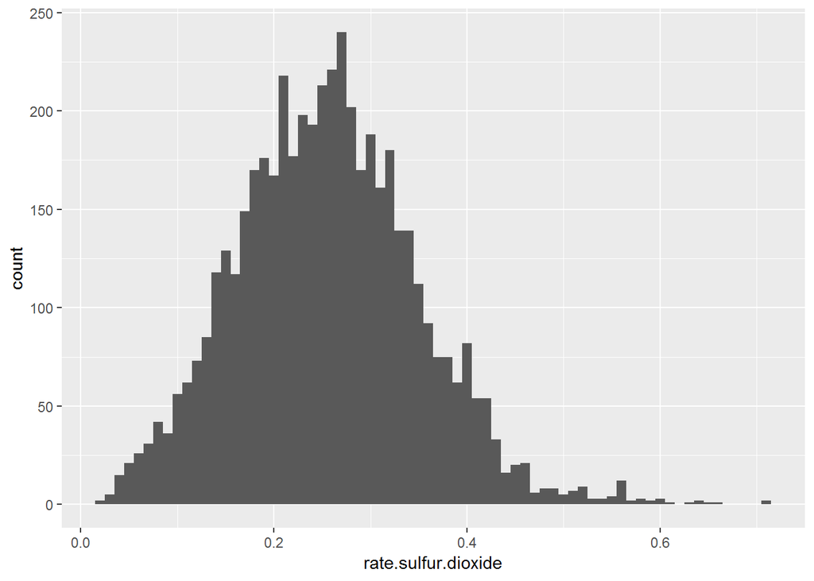

```r
# 绘制 rate.sulfur.dioxide 的直方图
ggplot(aes(x = rate.sulfur.dioxide), data = ww) +
  # 设置直方图宽度
  geom_histogram(binwidth = 0.01) +
  scale_x_continuous()
```

```r
# 查看 rate.sulfur.dioxide 的统计信息
summary(ww$rate.sulfur.dioxide)
```

```
##    Min. 1st Qu.  Median    Mean 3rd Qu.    Max.
## 0.02362 0.19093 0.25368 0.25558 0.31579 0.71053
```

游离二氧化硫比例的分布近似于正态分布，大多数在0.1~0.4之间，中位数为0.254， 平均数为0.256。

# 单变量分析

### 你的数据集结构是什么？

这个整齐的数据集包含4,898 种白葡萄酒，及 11个关于每种酒化学成分的变量。 至少3名葡萄酒专家对每种酒的质量进行了评分，分数在 0（非常差）和 10（非常好）之间。

### 你的数据集内感兴趣的主要特性有哪些？

数据集中的主要特征是质量评分。我想分析哪些化学成分影响白葡萄酒的质量？

### 你认为数据集内哪些其他特征可以帮助你探索兴趣特点？

固定酸度、残糖、氯化物、密度、酒精、游离二氧化硫比例可以帮助我探索兴趣特点。

### 根据数据集内已有变量，你是否创建了任何新变量？

创建游离二氧化硫比例，计算公式为free.sulfur.dioxide除以total.sulfur.dioxide。 创建质量评分的分类变量，分类区间为 “(2,4]” “(4,5]” “(5,6]” “(6,7]” “(7,9]”。

### 在已经探究的特性中，是否存在任何异常分布？你是否对数据进行一些操作，如清洁、调整或改变数据的形式？如果是，你为什么会这样做？

残糖的分布存在异常。我对残糖的数据进行了log10转换后发现， 分布图由右偏分布转换为双峰分布。

转换长尾数据以更好地了解残糖分布。转换残糖分布是双峰分布， 残糖含量大约在2左右和10左右。

# 双变量绘图选择

1.固定酸度与质量评分的散点图

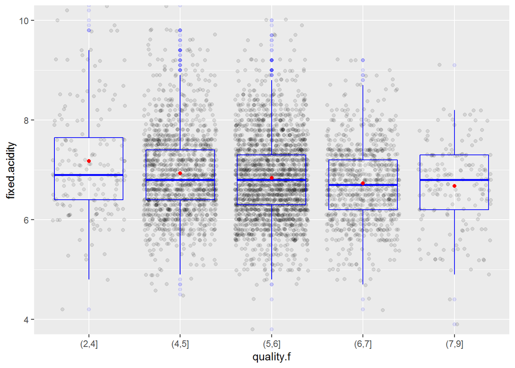

```r
# 绘制 quality 和 fixed.acidity 的散点图和箱线图
ggplot(aes(x = quality.f, y = fixed.acidity), data = ww) +
  # 给散点图添加噪声
  geom_jitter(alpha = 1/10) +
  # 绘制箱线图
  geom_boxplot(alpha = 1/10, color = 'blue') +
  # 添加平均值
  stat_summary(fun.y = 'mean', geom = 'point', color = 'red') +
  # 添加y值的范围
  coord_cartesian(ylim = c(4,10))
```

```r
# 查看 fixed.acidity 的统计信息
by(ww$fixed.acidity,ww$quality.f,summary)
```

```
## ww$quality.f: (2,4]
##    Min. 1st Qu.  Median    Mean 3rd Qu.    Max.
##   4.200   6.400   6.900   7.181   7.650  11.800
## --------------------------------------------------------
## ww$quality.f: (4,5]
##    Min. 1st Qu.  Median    Mean 3rd Qu.    Max.
##   4.500   6.400   6.800   6.934   7.400  10.300
## --------------------------------------------------------
## ww$quality.f: (5,6]
##    Min. 1st Qu.  Median    Mean 3rd Qu.    Max.
##   3.800   6.300   6.800   6.838   7.300  14.200
## --------------------------------------------------------
## ww$quality.f: (6,7]
##    Min. 1st Qu.  Median    Mean 3rd Qu.    Max.
##   4.200   6.200   6.700   6.735   7.200   9.200
## --------------------------------------------------------
## ww$quality.f: (7,9]
##    Min. 1st Qu.  Median    Mean 3rd Qu.    Max.
##   3.900   6.200   6.800   6.678   7.300   9.100
```

```r
# 查看 quality 和 fixed.acidity 的相关系数
cor.test(ww$fixed.acidity, ww$quality, method = 'pearson')
```

```
##
##  Pearson's product-moment correlation
##
## data:  ww$fixed.acidity and ww$quality
## t = -8.005, df = 4896, p-value = 1.48e-15
## alternative hypothesis: true correlation is not equal to 0
## 95 percent confidence interval:
##  -0.14121974 -0.08592991
## sample estimates:
##        cor
## -0.1136628
```

固定酸度越高质量评分越低，呈负相关，相关性为-0.11，说明两者是极弱相关。

2.残糖与质量评分的散点图

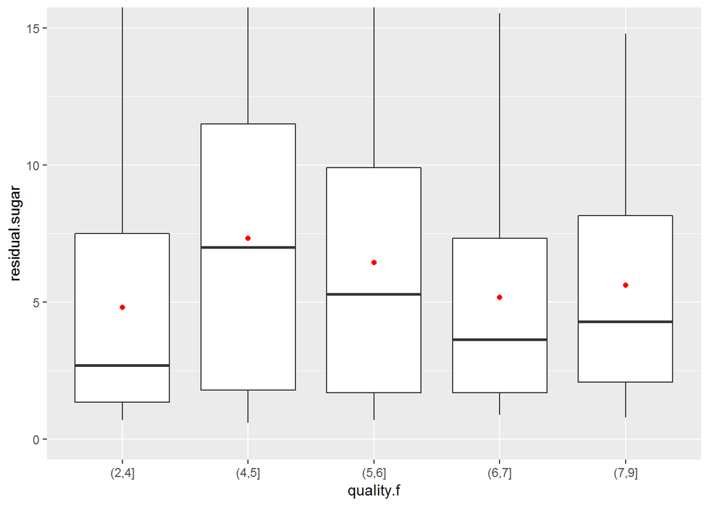

```r
# 绘制 quality 和 residual.sugar 的箱线图
ggplot(aes(x = quality.f, y = residual.sugar), data = ww) +
  geom_boxplot() +
  # 限制y值的范围
  coord_cartesian(ylim = c(0,15)) +
  # 添加平均值
  stat_summary(fun.y = 'mean', geom = 'point', color = 'red')
```

```r
# 查看 quality 和 residual.sugar 的相关系数
cor.test(ww$residual.sugar, ww$quality, method = 'pearson')
```

```
##
##  Pearson's product-moment correlation
##
## data:  ww$residual.sugar and ww$quality
## t = -6.8603, df = 4896, p-value = 7.724e-12
## alternative hypothesis: true correlation is not equal to 0
## 95 percent confidence interval:
##  -0.12524103 -0.06976101
## sample estimates:
##         cor
## -0.09757683
```

残糖越高质量评分越低，呈负相关，相关性为-0.10，说明两者是极弱相关。

```r
summary(ww$residual.sugar)
```

```
##    Min. 1st Qu.  Median    Mean 3rd Qu.    Max.
##   0.600   1.700   5.200   6.391   9.900  65.800
```

比较有趣的是，虽然残糖的全距达到65.2，但与质量评价的相关系数只有-0.10， 比预期中的关系弱很多。

3.氯化物与质量评分的散点图

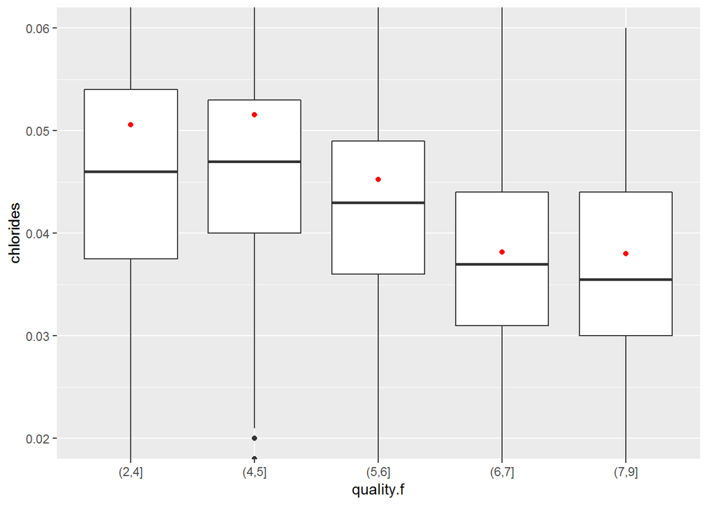

```r
# 绘制 quality 和 chlorides 的箱线图
ggplot(aes(x = quality.f, y = chlorides), data = ww) +
  geom_boxplot() +
  # 限制y值的范围
  coord_cartesian(ylim = c(0.02,0.06)) +
  # 添加平均值
  stat_summary(fun.y = 'mean', geom = 'point', color = 'red')
```

```r
# 查看 quality 和 chlorides 的相关系数
cor.test(ww$chlorides, ww$quality, method = 'pearson')
```

```
##
##  Pearson's product-moment correlation
##
## data:  ww$chlorides and ww$quality
## t = -15.024, df = 4896, p-value < 2.2e-16
## alternative hypothesis: true correlation is not equal to 0
## 95 percent confidence interval:
##  -0.2365501 -0.1830039
## sample estimates:
##        cor
## -0.2099344
```

氯化物越高质量评分越低，呈负相关，相关性为-0.21，说明两者是弱相关。

4.密度与质量评分的散点图

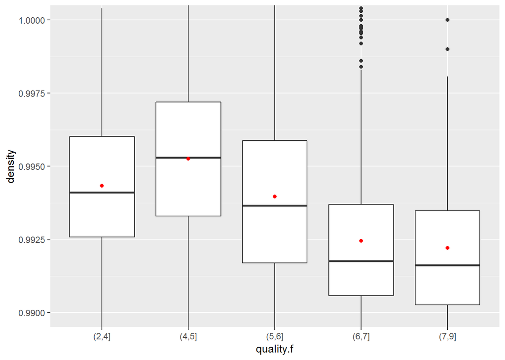

```r
# 绘制 quality 和 density 的箱线图
ggplot(aes(x = quality.f, y = density), data = ww) +
  geom_boxplot() +
  # 限制y值的范围
  coord_cartesian(ylim = c(0.99,1)) +
  # 添加平均值
  stat_summary(fun.y = 'mean', geom = 'point', color = 'red')
```

```r
# 查看 quality 和 density 的相关系数
cor.test(ww$density, ww$quality, method = 'pearson')
```

```
##
##  Pearson's product-moment correlation
##
## data:  ww$density and ww$quality
## t = -22.581, df = 4896, p-value < 2.2e-16
## alternative hypothesis: true correlation is not equal to 0
## 95 percent confidence interval:
##  -0.3322718 -0.2815385
## sample estimates:
##        cor
## -0.3071233
```

密度越高质量评分越低，呈负相关，相关性为-0.31，说明两者是弱相关。

```r
# 查看 density 的统计信息
summary(ww$density)
```

```
##    Min. 1st Qu.  Median    Mean 3rd Qu.    Max.
##  0.9871  0.9917  0.9937  0.9940  0.9961  1.0390
```

5.酒精与质量评分的散点图

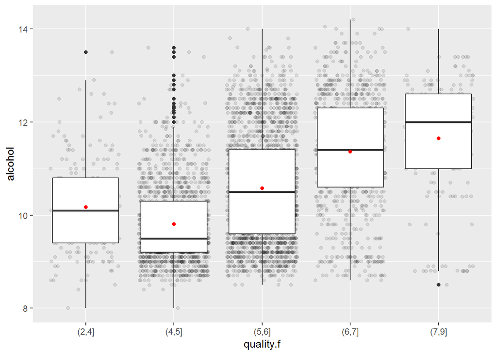

```r
# 绘制 quality 和 alcohol 的散点图和箱线图
ggplot(aes(x = quality.f, y = alcohol), data = ww) +
  # 给散点图添加噪声
  geom_jitter(alpha = 1/10) +
  # 绘制箱线图
  geom_boxplot() +
  # 添加平均值
  stat_summary(fun.y = 'mean', geom = 'point', color = 'red')
```

```r
# 查看 quality 和 alcohol 的相关系数
cor.test(ww$alcohol, ww$quality, method = 'pearson')
```

```
##
##  Pearson's product-moment correlation
##
## data:  ww$alcohol and ww$quality
## t = 33.858, df = 4896, p-value < 2.2e-16
## alternative hypothesis: true correlation is not equal to 0
## 95 percent confidence interval:
##  0.4126015 0.4579941
## sample estimates:
##       cor
## 0.4355747
```

酒精越高质量评分越高，呈正相关，相关系数为0.44，说明两者是中等相关。 从目前双变量分析中发现，质量与酒精的相关系数最高。

6.游离二氧化硫比例与质量评分的散点图

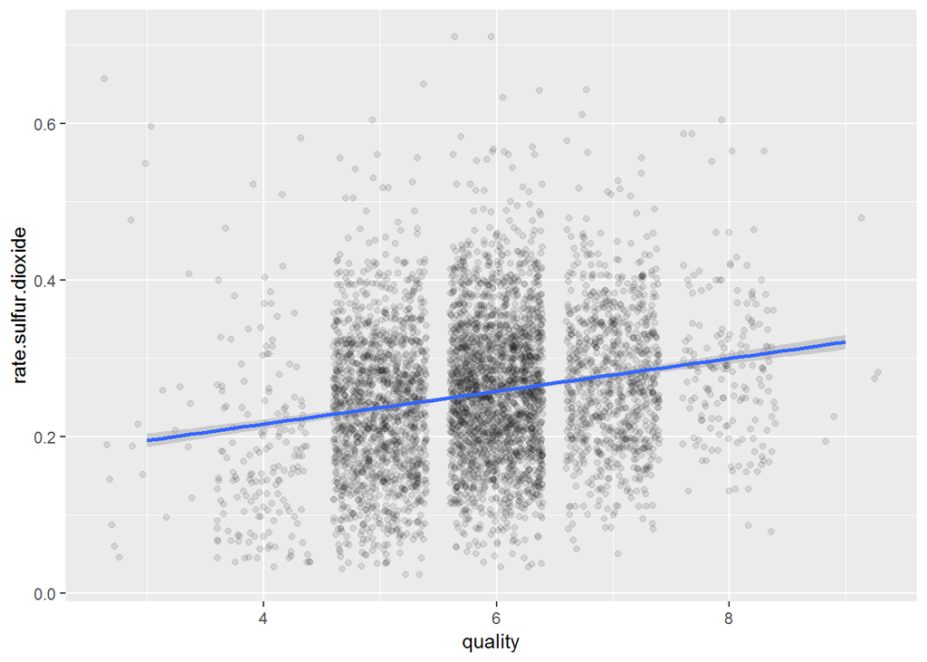

```r
# 绘制 quality 和 rate.sulfur.dioxide 的箱线图
ggplot(aes(x = quality, y = rate.sulfur.dioxide), data = ww) +
  # 给散点图添加噪声
  geom_jitter(alpha = 1/10) +
  # 绘制线性模型图
  geom_smooth(method = lm)
```

```r
# 查看 rate.sulfur.dioxide 和 quality 的统计信息
by(ww$rate.sulfur.dioxide,ww$quality.f,summary)
```

```
## ww$quality.f: (2,4]
##    Min. 1st Qu.  Median    Mean 3rd Qu.    Max.
## 0.03371 0.10543 0.16129 0.18883 0.23852 0.65682
## --------------------------------------------------------
## ww$quality.f: (4,5]
##    Min. 1st Qu.  Median    Mean 3rd Qu.    Max.
## 0.02362 0.17188 0.23810 0.23772 0.29646 0.65000
## --------------------------------------------------------
## ww$quality.f: (5,6]
##    Min. 1st Qu.  Median    Mean 3rd Qu.    Max.
## 0.03361 0.19836 0.25862 0.26217 0.32046 0.71053
## --------------------------------------------------------
## ww$quality.f: (6,7]
##    Min. 1st Qu.  Median    Mean 3rd Qu.    Max.
##  0.0500  0.2118  0.2717  0.2757  0.3333  0.6429
## --------------------------------------------------------
## ww$quality.f: (7,9]
##    Min. 1st Qu.  Median    Mean 3rd Qu.    Max.
## 0.07895 0.22308 0.28767 0.28929 0.33621 0.60377
```

```r
# 查看 quality 和 rate.sulfur.dioxide 的相关系数
cor.test(ww$rate.sulfur.dioxide, ww$quality, method = 'pearson')
```

```
##
##  Pearson's product-moment correlation
##
## data:  ww$rate.sulfur.dioxide and ww$quality
## t = 14.076, df = 4896, p-value < 2.2e-16
## alternative hypothesis: true correlation is not equal to 0
## 95 percent confidence interval:
##  0.1701474 0.2239834
## sample estimates:
##       cor
## 0.1972141
```

游离二氧化硫比例越高质量评分越高，呈正相关，相关性为0.20，说明两者是弱相关。

# 双变量分析

### 探讨你在这部分探究中观察到的一些关系。这些感兴趣的特性与数据集内其他特性有什么区别？

酒精、游离二氧化硫比例与质量评分是正相关，且前者是中等相关，后者是弱相关。

氯化物、密度与质量评分是负相关，且两者都是弱相关。

固定酸度、残糖与质量评分是负相关，且两者都是极弱相关。

### 你是否观察到主要特性与其他特性之间的有趣关系？

质量评分与酒精、密度、氯化物、游离二氧化硫比例相关。

残糖的全距达到65.2，但与质量评价的相关系数只有-0.10，比预期中的关系弱很多。

酒精和质量评分的相关性为中等正相关，且相关系数为0.44，这是双变量分析中的最强相关。

### 你发现最强的关系是什么？

酒精与质量评分是最强正相关。密度与质量评分是最强负相关。

# 多变量绘图选择

1.质量评分、酒精与密度的分析图

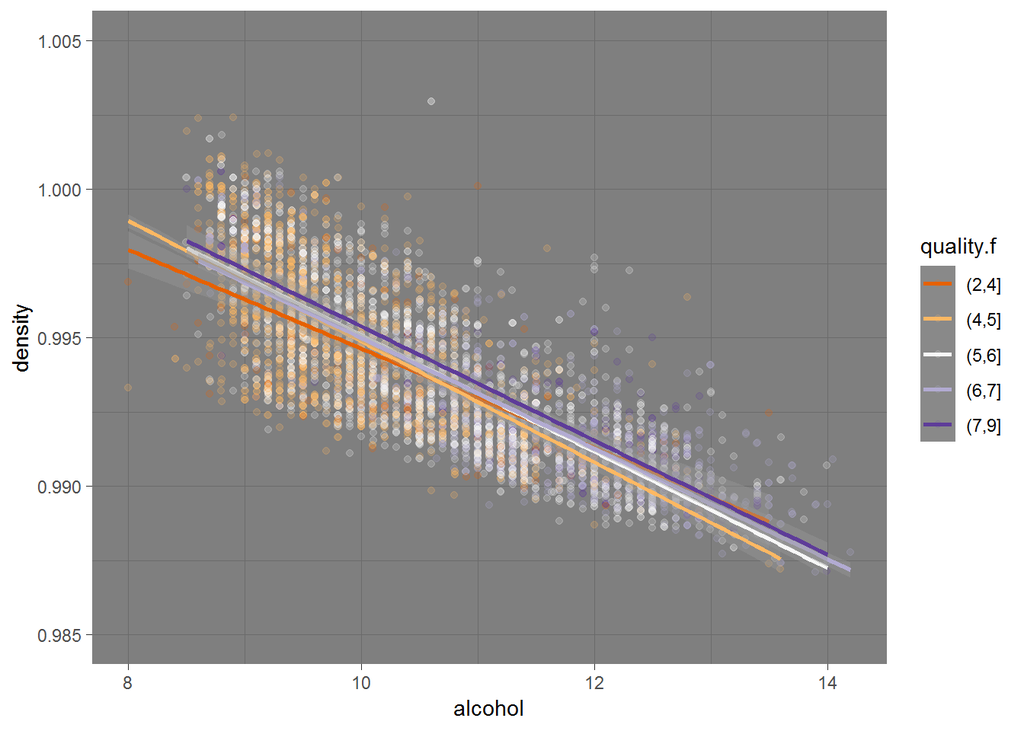

```r
# 绘制 alchol, density 和 quality 的散点图
ggplot(aes(x = alcohol, y = density, color = quality.f), data = ww) +
  # 给散点图添加噪声
  geom_jitter(alpha = 1/5) +
  # 限制y值的范围
  coord_cartesian(ylim = c(0.985,1.005)) +
  # 设置颜色
  scale_color_brewer(type = 'div', palette = 'PuOr') +
  # 设置背景图
  theme_dark()  +
  # 绘制线性模型图
  geom_smooth(method = lm)
```

质量评分越高，酒精含量也会越高，但密度会降低。

2.质量评分、酒精与氯化物的分析图

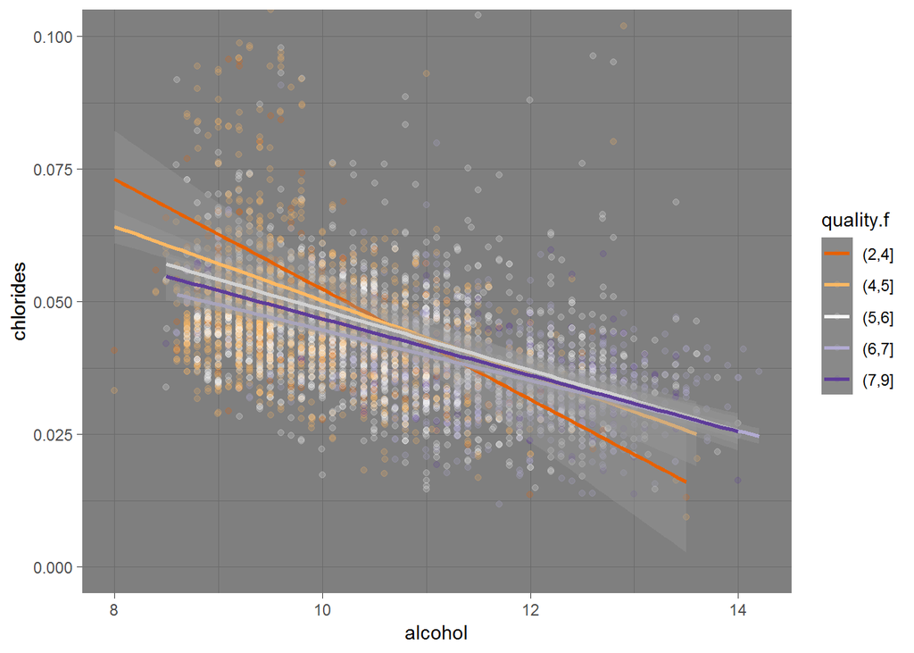

```r
# 绘制 alchol, chlorides 和 quality 的散点图
ggplot(aes(x = alcohol, y = chlorides, color = quality.f), data = ww) +
  # 给散点图添加噪声
  geom_jitter(alpha = 1/5) +
  # 限制y值的范围
  coord_cartesian(ylim = c(0,0.1)) +
  # 设置颜色
  scale_color_brewer(type = 'div', palette = 'PuOr') +
  # 设置背景图
  theme_dark()  +
  # 绘制线性模型图
  geom_smooth(method = lm)
```

质量评分越高，酒精含量也越高，但氯化物越低。

3.质量评分、酒精与游离二氧化硫比例的分析图

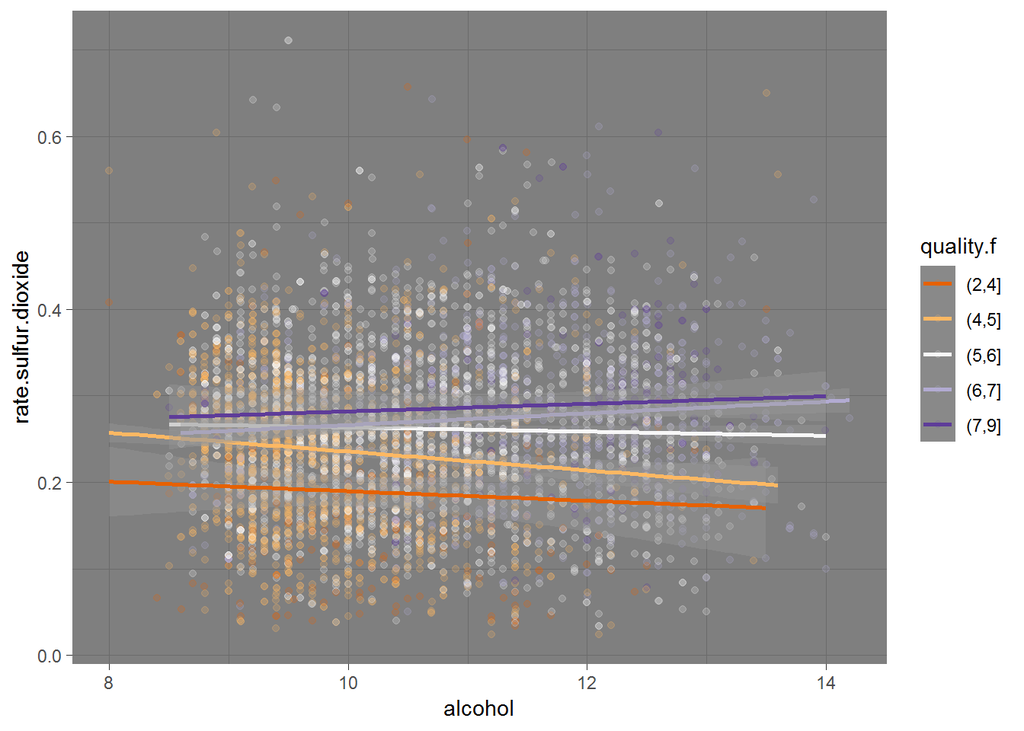

```r
# 绘制 alchol, rate.sulfur.dioxide 和 quality 的散点图
ggplot(aes(x = alcohol, y = rate.sulfur.dioxide, color = quality.f), data = ww) +
  # 给散点图添加噪声
  geom_jitter(alpha = 1/5) +
  # 限制y值的范围
  coord_cartesian() +
  # 设置颜色
  scale_color_brewer(type = 'div', palette = 'PuOr') +
  # 设置背景图
  theme_dark()  +
  # 绘制线性模型图
  geom_smooth(method = lm)
```

质量高于7分时，分数越高，酒精含量也越高，游离二氧化硫比例越高。 但质量低于7分时，分数越高，酒精含量也越高，但游离二氧化硫比例会降低。

```r
# 查看 quality 和 rate.sulfur.dioxide 的相关系数
cor.test(ww$rate.sulfur.dioxide, ww$quality, method = 'pearson')
```

```
##
##  Pearson's product-moment correlation
##
## data:  ww$rate.sulfur.dioxide and ww$quality
## t = 14.076, df = 4896, p-value < 2.2e-16
## alternative hypothesis: true correlation is not equal to 0
## 95 percent confidence interval:
##  0.1701474 0.2239834
## sample estimates:
##       cor
## 0.1972141
```

虽然游离二氧化硫比例和质量是正相关，但是质量在高于7分和低于7分时，线性关系不一致。

4.质量评分、密度与氯化物的分析图

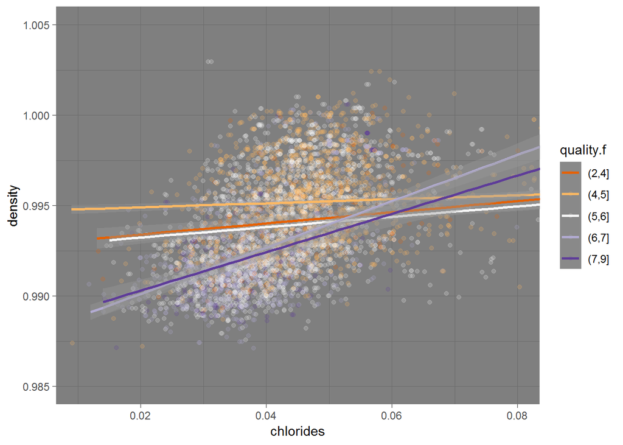

```r
# 绘制 chlorides, density 和 quality 的散点图
ggplot(aes(x = chlorides, y = density, color = quality.f), data = ww) +
  # 给散点图添加噪声
  geom_jitter(alpha = 1/5) +
  # 限制x值和y值的范围
  coord_cartesian(xlim = c(0.01,0.08), ylim = c(0.985,1.005)) +
  # 设置颜色
  scale_color_brewer(type = 'div', palette = 'PuOr') +
  # 设置背景图
  theme_dark()  +
  # 绘制线性模型图
  geom_smooth(method = lm)
```

质量评分越高，密度越低，氯化物也越低。

1.创建线性模型

```r
# 创建 quality ~ alcohol 的线性模型
m1 <- lm(I(quality) ~ I(alcohol), data=ww)
# 在m1中添加变量 rate.sulfur.dioxide
m2 <- update(m1, ~ . + rate.sulfur.dioxide)
# 在m2中添加变量 chlorides
m3 <- update(m2, ~ . + chlorides)
# 在m3中添加变量 density
m4 <- update(m3, ~ . + density)
mtable(m1,m2,m3,m4)
```

```
##
## Calls:
## m1: lm(formula = I(quality) ~ I(alcohol), data = ww)
## m2: lm(formula = I(quality) ~ I(alcohol) + rate.sulfur.dioxide, data = ww)
## m3: lm(formula = I(quality) ~ I(alcohol) + rate.sulfur.dioxide +
##     chlorides, data = ww)
## m4: lm(formula = I(quality) ~ I(alcohol) + rate.sulfur.dioxide +
##     chlorides + density, data = ww)
##
## ===============================================================================
##                             m1            m2            m3            m4
## -------------------------------------------------------------------------------
##   (Intercept)              2.582***      2.256***      2.527***    -23.520***
##                           (0.098)       (0.099)       (0.117)       (6.053)
##   I(alcohol)               0.313***      0.306***      0.290***      0.340***
##                           (0.009)       (0.009)       (0.010)       (0.015)
##   rate.sulfur.dioxide                    1.600***      1.595***      1.607***
##                                         (0.119)       (0.119)       (0.119)
##   chlorides                                           -2.392***     -2.295***
##                                                       (0.548)       (0.548)
##   density                                                           25.675***
##                                                                     (5.966)
## -------------------------------------------------------------------------------
##   R-squared                0.190         0.218         0.221         0.224
##   adj. R-squared           0.190         0.218         0.221         0.224
##   sigma                    0.797         0.783         0.782         0.780
##   F                     1146.395       684.102       464.098       353.950
##   p                        0.000         0.000         0.000         0.000
##   Log-likelihood       -5839.391     -5750.993     -5741.480     -5732.227
##   Deviance              3112.257      3001.921      2990.283      2979.007
##   AIC                  11684.782     11509.987     11492.961     11476.455
##   BIC                  11704.272     11535.973     11525.444     11515.434
##   N                     4898          4898          4898          4898
## ===============================================================================
```

该线性模型中的变量可占质量评分的22.4％。即使单独使用质量评分和酒精的转换， 仍然占的19.0％。

# 多变量分析

### 探讨你在这部分探究中观察到的一些关系。通过观察感兴趣的特性，是否存在相互促进的特性？

质量评分、酒精、密度、氯化物和游离二氧化硫比例的关系。

### 这些特性之间是否存在有趣或惊人的联系呢？

质量评分越高，酒精含量也越高，密度和氯化物越低。

质量评分越高，密度越低，氯化物越低。

质量评分高于7分时，分数越高，酒精含量也越高，游离二氧化硫比例越高，但质量评分 低于7分时，分数越高，酒精含量也越高，但游离二氧化硫比例会降低。虽然游离二氧化硫 比例和质量评分是正相关，且相关系数是0.20，但是质量在高于7分和低于7分时，线性关系 不一致。

### 选项：你是否创建过数据集的任何模型？讨论你模型的优缺点。

是的，我创建了线性模型。从线性模型中，可以直接得出哪些化学成分对白葡萄酒的质量 相关关系最强和最弱，这样能从这些方面开始分析数据和建立模型。

# 定稿图与总结

### 绘图一

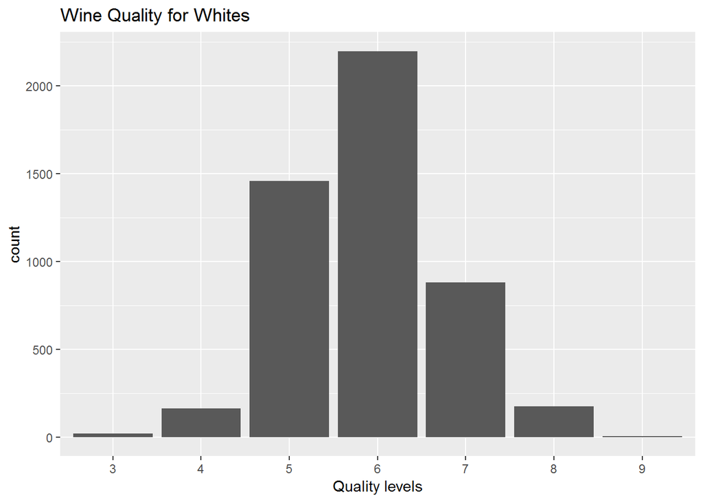

### 描述一

白葡萄酒的质量评分的分布近似于正态分布，大多数在5分~7分之间。

### 绘图二

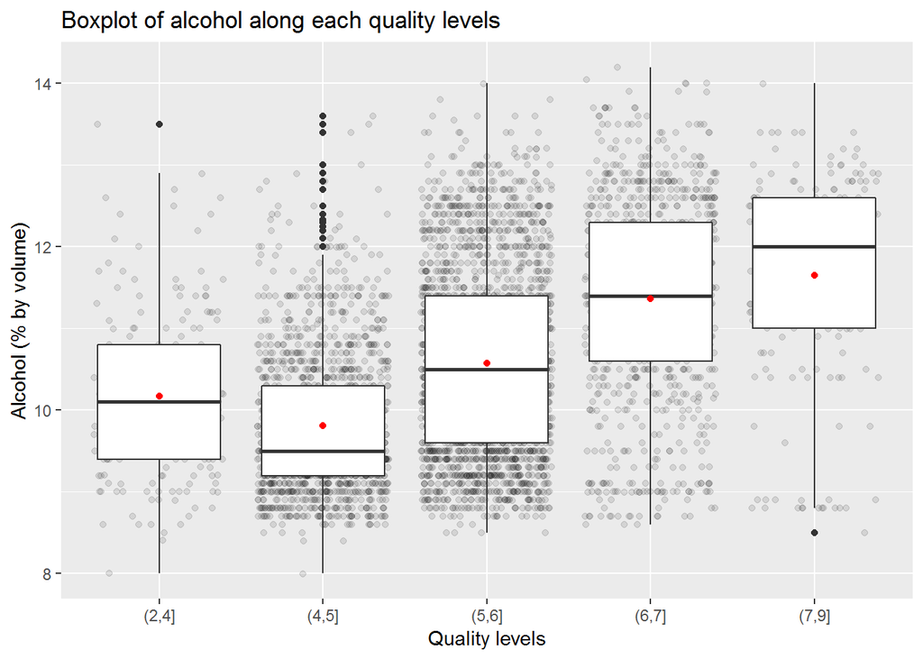

### 描述二

酒精含量越高质量评分越高，呈正相关。

### 绘图三

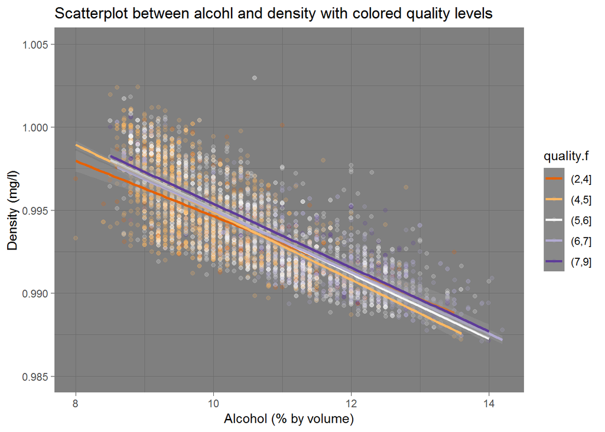

### 描述三

质量评分越高，酒精含量也会越高，但密度会降低。

# 反思

1）白葡萄酒数据集包含12个变量中4898个观测数据的信息。我通过分析了数据集中的 所有变量，然后在对分析图进行观察时探究了有趣的问题和线索。最后，我总结了质量 评价与几个主要的变量之间的关系，创建了一个预测质量评价的线性模型。

2）分析过程中遇到的难点是，当整体分布为正态分布，且存在异常点时，添加了5%，95% 的分位图，区别数据的集中范围。还有从残糖分布log10转换后的双峰分布，不知道需要 从哪方面继续分析。

3）在单变量分析中发现，几乎所有的分布都是近似于正态分布，只有残糖的分布存在 异常。残糖的分布是明显的右偏分布，为了更好的了解残糖分布的长尾数据，进行了log10 转换，分布图也由右偏分布转换成了双峰分布。得到残糖含量大约集中在2左右和10左右。

5）在多变量分析中发现，质量评分高于7分时，分数越高，酒精含量也越高，游离二氧 化硫比例越高，但质量评分低于7分时，分数越高，酒精含量也越高，但游离二氧化硫比 例会降低。虽然游离二氧化硫比例和质量评分是正相关，且相关系数是0.20，但是质量在 高于7分和低于7分时，线性关系不一致。

6）从线性模型中得知，质量评价与酒精、游离二氧化硫比例、氯化物和密度之间存在着明 显的趋势，但R-squared为仅仅0.224，觉得应该还有其他更主要的变量将影响着的质量评价。

7）由于数据集中，只有4898个观测数据，我还需要更大、更好的数据集来分析， 1.是否有其他变量与质量评价的线性关系更强， 2.残糖与质量的相关系数低是不是由异常点的原因造成的， 3.密度与质量的相关系数高是不是由于数据集的不充足造成的， 4.游离二氧化硫的比例与质量的线性关系的异常是不是由于数据集的不充足造成的。